# Problem Statement

**AtliQ Hardware** supplies hardware and peripherals to many hardware store clients. They have head office in Dehli and many regional offices.Their sales are growing rapidly and the Sales Director is having issue to keep insights of the growth as there are so many excel files.

# AIM'S GRID

## Purpose

In order to unlock the sales insights that are not visible to the marketing/sales teams for proper decision and strategy making

## Stakeholders

- Sales Director
- IT Team
- Data Analytics Team
- Marketing Team
- Customer Service Team

## Success Criteria

- Sales Insights and trends are available to the Sales Director and teams to provide Data Driven Decisions.
- Automated Procedure to save time taken manually

## End Result

A Power BI DashBoard to visualize and keep track of the latest sales insights

# Available Data Format

- MySQL DataBase (.sql file)

# Data Model

**Star Schema** is followed.

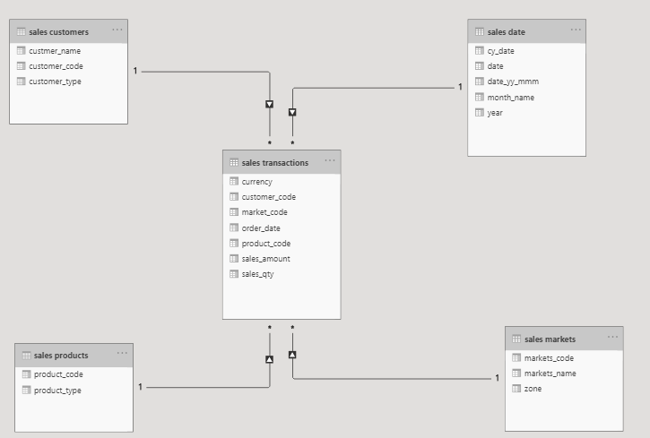

# Process Steps

### 1) ETL (Exrtact, Transform, Load)

- Extracted Data from mySQL database to Power BI
- Transformed Data Using Power Query
- Loaded transformed data into Power BI

### 2) Build a Dashboard

- Build a proper dashboard that will help the user to get **useful insights** from the records

### 3) Feedback on Dashboard from User

- As the stakeholders to use the Dashboard and provide feedback on what should be improved

# AtliQ Sales Insights Report/Dashboard

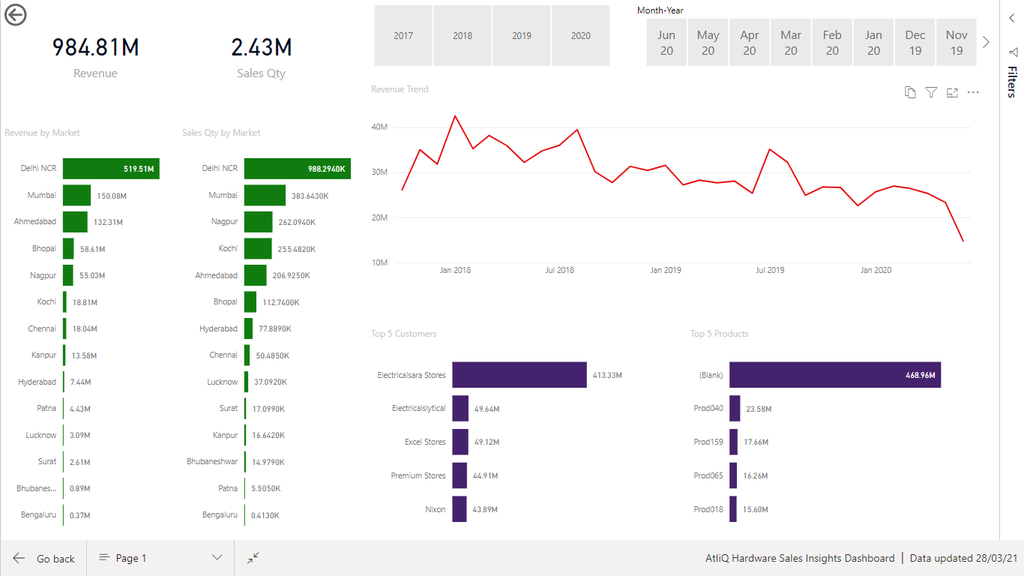

# AtliQ Sales Insights Report/Dashboard Mobile View

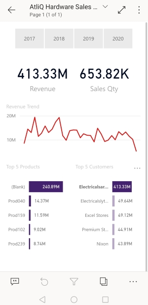